# Tarea Covid

Cayetano

2023-02-11

## Descarga de los datos

1 Los data frame’s de datos contienen información de los países, los casos contabilidados a diario, así como coordenadas geográficas.

1.2 Tarea solicitada

La tarea solicitada está completamente abierta y el objetivo final es mostrar una visualización espacial, sobre un mapa, con la evolución temporal de la enfermedad mostrando el número de infectados, fallecidos y recuperados.

Es muy importante que cuando se ejecute el programa se realice la descarga de los datos para que los mapas visualizados se correspondan con la última información disponible.

```r
df.confirmed <- read.csv('https://raw.githubusercontent.com/CSSEGISandData/COVID-19/master/csse_covid_19_data/csse_covid_19_time_series/time_series_covid19_confirmed_global.csv')
df.death <- read.csv('https://raw.githubusercontent.com/CSSEGISandData/COVID-19/master/csse_covid_19_data/csse_covid_19_time_series/time_series_covid19_deaths_global.csv')
df.recovered <- read.csv('https://raw.githubusercontent.com/CSSEGISandData/COVID-19/master/csse_covid_19_data/csse_covid_19_time_series/time_series_covid19_recovered_global.csv')
```

1.3 Contenidos mínimos. La solución propuesta tiene que incluir, al menos, los siguientes aspectos: • Debe incluir la descarga de un mapa para mostrar la información. • Debe añadir al mapa la información a representar (data frame asociado al objeto sp). • Debe mostrar una animación de la evolución de la enfermedad (infectados, fallecidos y recuperados) 1.4 Qué se entrega. Se debe entregar un proyecto llamado VisualizaCovid19 que debe ser completamente funcional, incluyendo la instalación de librerías adicionales, si fuese necesaria. 1.5 Plazo. La fecha límite de entrega es el día 5-6-2023 (fecha de la primera convocatoria de la asignatura)

```r
load_packages <- function(packages) {
  # Comprobamos si cada paquete especificado está instalado
  missing_packages <- packages[!sapply(packages, requireNamespace, quietly = TRUE)]

  # Si faltan paquetes, los instalamos
  if (length(missing_packages) > 0) {
    install.packages(missing_packages)
  }

  # Cargamos todos los paquetes especificados
  invisible(sapply(packages, library, character.only = TRUE))
}

load_packages(c("tidyverse", "ggplot2", "gganimate", "tmap", "sf", "stringr", "transformr", "scales"))
```

# CONFIRMADOS

```r
data(World)
mundo <- arrange(World, name)

referencia <- data.frame(
  correcto = c("Bosnia and Herz.", "Central African Rep.", "Congo","Dem. Rep. Congo", "Czech Rep.", "Dominican Rep.","Eq. Guinea", "Dem. Rep. Korea", "Korea","Lao PDR", "Macedonia", "Myanmar","Palestine", "S. Sudan", "Solomon Is.", "Swaziland", "Taiwan", "United States"),
  incorrecto = c("Bosnia and Herzegovina", "Central African Republic", "Congo (Brazzaville)","Congo (Kinshasa)", "Czechia", "Dominican Republic","Equatorial Guinea", "Korea, North", "Korea, South", "Laos", "North Macedonia", "Burma","West Bank and Gaza", "South Sudan", "Solomon Islands", "Eswatini", "Taiwan*", "US")
)

paises_corregidos <- left_join(df.confirmed, referencia, by = c("Country.Region" = "incorrecto"))

confirmados_final <- paises_corregidos %>%
  mutate(name = ifelse(is.na(correcto), Country.Region, correcto)) %>%
  select(-correcto)

confirmados_final$Country.Region <- confirmados_final$name
confirmados_final <- confirmados_final %>% select(-c(name, Province.State))



confirmados_final <- confirmados_final %>%
  group_by(Country.Region) %>%
  summarize_if(is.numeric, sum)

confirmados_final2 <- mundo %>% inner_join(confirmados_final, by = c('name' = 'Country.Region'))
```

```r
confirmados_melted <- confirmados_final2 %>%
  select(-c(iso_a3, sovereignt, continent, area, pop_est, pop_est_dens, income_grp, economy, gdp_cap_est, footprint, well_being, inequality, HPI, Lat, Long, life_exp)) %>%
  pivot_longer(-c(name, geometry), names_to = "fecha", values_to = "casos")

confirmados_melted$fecha <- str_replace_all(confirmados_melted$fecha,'X', '')


confirmados_melted$fecha <- lapply(confirmados_melted$fecha, function(x){
  if(substr(x, 2, 2) == "."){
    paste0("0", x)
  }else{
    x
  }
})

confirmados_melted$fecha <- lapply(confirmados_melted$fecha, function(x){
  if(substr(x, 5, 5) == "."){
    paste0(substr(x, 1, 3), "0", substr(x, 4, nchar(x)))
  }else{
    x
  }
})


confirmados_melted$fecha <- gsub("\\.", "-", confirmados_melted$fecha)

confirmados_melted$fecha <- sapply(confirmados_melted$fecha, function(x) {
  primer_segmento <- substr(x, 4, 5)
  segundo_segmento <- substr(x, 1, 2)
  tercer_segmento <- substr(x, 6, 8)
  return(paste(primer_segmento, '-', segundo_segmento, tercer_segmento, sep = ''))
})
```

```r
length(unique(confirmados_melted$fecha))
```

```
## [1] 1143
```

```r
confirmados_melted$fecha <- as.Date(confirmados_melted$fecha, format = "%d-%m-%y")


CONFIRMADOS <- confirmados_melted
```

```r
p <- ggplot(CONFIRMADOS) +
  geom_sf(aes(fill = casos)) +
  scale_fill_gradientn(colours = c("white", "red"),
                       guide = guide_colourbar(title = "Casos",
                                               barheight = unit(0.5, "in"),
                                               barwidth = unit(0.2, "in")),
                       labels = scales::label_number(),
                       trans = "log") +
  theme_void() +
  theme(plot.title = element_text(size = 5),
        legend.text = element_text(size = 5),
        legend.title = element_text(size = 5))


anim <- p + transition_time(fecha) +
  labs(title = "   Casos confirmados el día {frame_time}") +
  ease_aes('sine-in-out')


anim_CONF <- animate(anim, width = 800, height = 600, res = 300, fps = 5, duration = 15)
anim_save("confirmados.gif", anim_CONF)
```

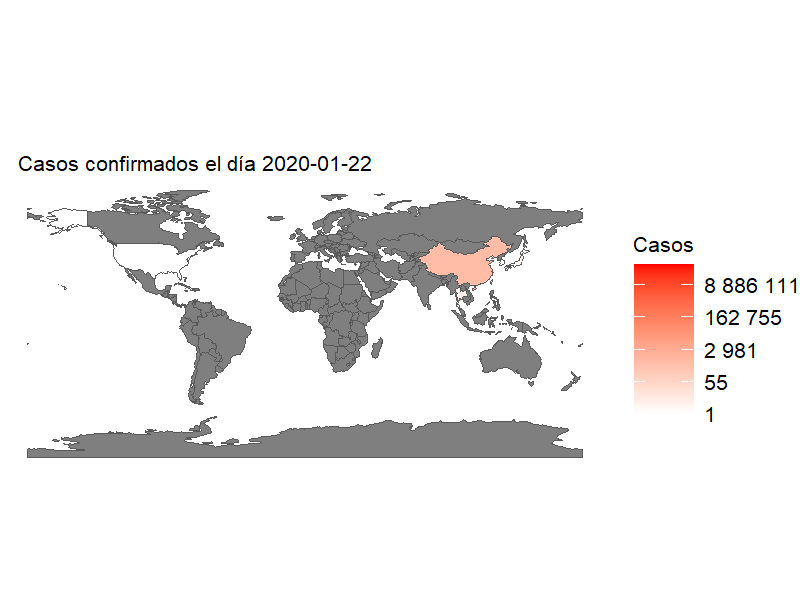

```r
anim_CONF
```

# FALLECIDOS

```r
data(World)
mundo <- arrange(World, name)

referencia <- data.frame(
  correcto = c("Bosnia and Herz.", "Central African Rep.", "Congo","Dem. Rep. Congo", "Czech Rep.", "Dominican Rep.","Eq. Guinea", "Dem. Rep. Korea", "Korea","Lao PDR", "Macedonia", "Myanmar","Palestine", "S. Sudan", "Solomon Is.", "Swaziland", "Taiwan", "United States"),
  incorrecto = c("Bosnia and Herzegovina", "Central African Republic", "Congo (Brazzaville)","Congo (Kinshasa)", "Czechia", "Dominican Republic","Equatorial Guinea", "Korea, North", "Korea, South", "Laos", "North Macedonia", "Burma","West Bank and Gaza", "South Sudan", "Solomon Islands", "Eswatini", "Taiwan*", "US")
)

paises_corregidos <- left_join(df.death, referencia, by = c("Country.Region" = "incorrecto"))

fallecidos_final <- paises_corregidos %>%
  mutate(name = ifelse(is.na(correcto), Country.Region, correcto)) %>%
  select(-correcto)

fallecidos_final$Country.Region <- fallecidos_final$name
fallecidos_final <- fallecidos_final %>% select(-c(name, Province.State))

fallecidos_final <- fallecidos_final %>%
  group_by(Country.Region) %>%
  summarize_if(is.numeric, sum)

fallecidos_final2 <- mundo %>% inner_join(fallecidos_final, by = c('name' = 'Country.Region'))
```

```r
fallecidos_melted <- fallecidos_final2 %>%
  select(-c(iso_a3, sovereignt, continent, area, pop_est, pop_est_dens, income_grp, economy, gdp_cap_est, footprint, well_being, inequality, HPI, Lat, Long, life_exp)) %>%
  pivot_longer(-c(name, geometry), names_to = "fecha", values_to = "casos")

fallecidos_melted$fecha <- str_replace_all(fallecidos_melted$fecha,'X', '')


fallecidos_melted$fecha <- lapply(fallecidos_melted$fecha, function(x){
  if(substr(x, 2, 2) == "."){
    paste0("0", x)
  }else{
    x
  }
})

fallecidos_melted$fecha <- lapply(fallecidos_melted$fecha, function(x){
  if(substr(x, 5, 5) == "."){
    paste0(substr(x, 1, 3), "0", substr(x, 4, nchar(x)))
  }else{
    x
  }
})


fallecidos_melted$fecha <- gsub("\\.", "-", fallecidos_melted$fecha)

fallecidos_melted$fecha <- sapply(fallecidos_melted$fecha, function(x) {
  primer_segmento <- substr(x, 4, 5)
  segundo_segmento <- substr(x, 1, 2)
  tercer_segmento <- substr(x, 6, 8)
  return(paste(primer_segmento, '-', segundo_segmento, tercer_segmento, sep = ''))
})
```

```r
fallecidos_melted$fecha <- as.Date(fallecidos_melted$fecha, format = "%d-%m-%y")

FALLECIDOS <- fallecidos_melted
```

```r
f <- ggplot(FALLECIDOS) +
  geom_sf(aes(fill = casos)) +
  scale_fill_gradientn(colours = c("white", "red"),
                       guide = guide_colourbar(title = "Total Fallecidos",
                                               barheight = unit(0.5, "in"),
                                               barwidth = unit(0.2, "in")),
                       labels = scales::label_number(),
                       trans = "log") +
  theme_void() +
  theme(plot.title = element_text(size = 5),
        legend.text = element_text(size = 5),
        legend.title = element_text(size = 5))


anim <- f + transition_time(fecha) +
  labs(title = "   Nº Fallecidos totales al día {frame_time}") +
  ease_aes('sine-in-out')


anim_FAL <- animate(anim, width = 800, height = 600, res = 300, fps = 5, duration = 15)
anim_save("fallecidos.gif", anim_FAL)
```

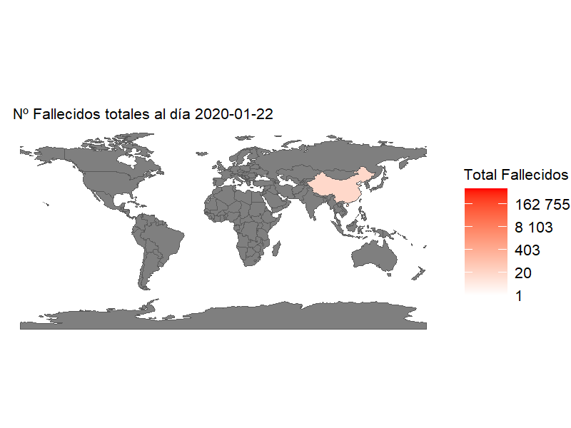

```r
anim_FAL
```

# RECUPERADOS

```r
data(World)
mundo <- arrange(World, name)

referencia <- data.frame(
  correcto = c("Bosnia and Herz.", "Central African Rep.", "Congo","Dem. Rep. Congo", "Czech Rep.", "Dominican Rep.","Eq. Guinea", "Dem. Rep. Korea", "Korea","Lao PDR", "Macedonia", "Myanmar","Palestine", "S. Sudan", "Solomon Is.", "Swaziland", "Taiwan", "United States"),
  incorrecto = c("Bosnia and Herzegovina", "Central African Republic", "Congo (Brazzaville)","Congo (Kinshasa)", "Czechia", "Dominican Republic","Equatorial Guinea", "Korea, North", "Korea, South", "Laos", "North Macedonia", "Burma","West Bank and Gaza", "South Sudan", "Solomon Islands", "Eswatini", "Taiwan*", "US")
)

paises_corregidos <- left_join(df.recovered, referencia, by = c("Country.Region" = "incorrecto"))

recuperados_final <- paises_corregidos %>%
  mutate(name = ifelse(is.na(correcto), Country.Region, correcto)) %>%
  select(-correcto)

recuperados_final$Country.Region <- recuperados_final$name
recuperados_final <- recuperados_final %>% select(-c(name, Province.State))

recuperados_final <- recuperados_final %>%
  group_by(Country.Region) %>%
  summarize_if(is.numeric, sum)

recuperados_final2 <- mundo %>% inner_join(recuperados_final, by = c('name' = 'Country.Region'))
```

```r
recuperados_melted <- recuperados_final2 %>%
  select(-c(iso_a3, sovereignt, continent, area, pop_est, pop_est_dens, income_grp, economy, gdp_cap_est, footprint, well_being, inequality, HPI, Lat, Long, life_exp)) %>%
  pivot_longer(-c(name, geometry), names_to = "fecha", values_to = "casos")

recuperados_melted$fecha <- str_replace_all(recuperados_melted$fecha,'X', '')


recuperados_melted$fecha <- lapply(recuperados_melted$fecha, function(x){
  if(substr(x, 2, 2) == "."){
    paste0("0", x)
  }else{
    x
  }
})

recuperados_melted$fecha <- lapply(recuperados_melted$fecha, function(x){
  if(substr(x, 5, 5) == "."){
    paste0(substr(x, 1, 3), "0", substr(x, 4, nchar(x)))
  }else{
    x
  }
})


recuperados_melted$fecha <- gsub("\\.", "-", recuperados_melted$fecha)

recuperados_melted$fecha <- sapply(recuperados_melted$fecha, function(x) {
  primer_segmento <- substr(x, 4, 5)
  segundo_segmento <- substr(x, 1, 2)
  tercer_segmento <- substr(x, 6, 8)
  return(paste(primer_segmento, '-', segundo_segmento, tercer_segmento, sep = ''))
})
```

```r
recuperados_melted$fecha <- as.Date(recuperados_melted$fecha, format = "%d-%m-%y")


RECUPERADOS <- recuperados_melted
```

```r
r <- ggplot(RECUPERADOS) +
  geom_sf(aes(fill = casos)) +
  scale_fill_gradientn(colours = c("white", "red"),
                       guide = guide_colourbar(title = "Total Recuperados",
                                               barheight = unit(0.5, "in"),
                                               barwidth = unit(0.2, "in")),
                       labels = scales::label_number(),
                       trans = "log") +
  theme_void() +
  theme(plot.title = element_text(size = 5),
        legend.text = element_text(size = 5),
        legend.title = element_text(size = 5))


anim <- r + transition_time(fecha) +
  labs(title = "   Nº Recuperados totales totales al día {frame_time}") +
  ease_aes('sine-in-out')



anim_REC <- animate(anim, width = 800, height = 600, res = 300, fps = 5, duration = 15)
anim_save("recuperados.gif", anim_REC)
```

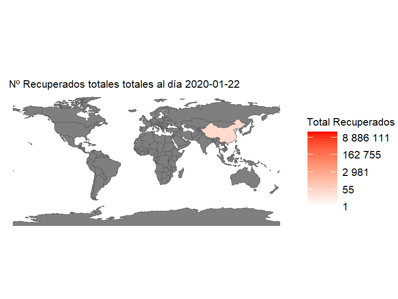

```r
anim_REC
```